# EXPRESIONES REGULARES

Teoría de la Computación  
2026-2

Walter Quispe Vargas

wquispev@utec.edu.pe  
Departamento de Ciencia de la Computación, UTEC

# CONTENIDO

- OBJETIVOS
- OPERACIONES REGULARES
  - Union, Concatenación, Estrella
- EXPRESIONES REGULARES
  - Definición
  - Lenguajes descritos por expresiones regulares
  - Equivalentecia entre Expresiones Regulares y AFD (AFN)
- CONCLUSIONES

# OBJETIVOS

- Conocer las operaciones regulares de lenguajes
- Analizar la operación de clausura
- Definir las expresiones regulares para describir lenguajes regulares

## OPERACIONES REGULARES

- **Operaciones Regulares**: Sean $A,B$ lenguajes Regulares, son tambien regulares:
  - Unión: $A\cup B=\{ w|w\in A \ or \ w\in B \}$
  - Concatenación: $A\cdot B=\{ xy|x\in A \ and \ y\in B \}=AB$
  - Estrella (Clausura): $A^*=\{ x_1x_2...x_k| x_i\in A, \ \ k\geq 0 \}$
- Si $L=\{0,1\}$
  - $L^{*} = \{w| w \mbox{ es una cadena de } 0s \mbox{ y/o } 1s\}$
- $L=\{0,11\}$
  - $L^{*} = \{w| w \mbox{ puede ser una cadena donde los } 1s \mbox{ aparecen en pares } \}$
- `DEFINICIÓN FORMAL DE CLAUSURA`
  - $L^{*} = \bigcup_{i \geq 0}L^{i} = L^{0} \cup L^{1} \cup \ldots$
  - Donde $L^{i}=\{w| w \mbox{ es la concatenación de } i \mbox{ cadenas en } L\}$
  - Observación: $L^{0} = \{\epsilon\}$
  - Por tanto $\epsilon$ siempre está en la clausura de **cualquier lenguaje**
  - $\emptyset^{*} = \{\epsilon\}$
- `Ejemplo`: Hallar la clausura de $L=\{0,11\}$
  - $L^{0} = \{\epsilon\}$
  - $L^{1} = \{0,11\}$
  - $L^{2} = \{00,011,110,1111\}$
  - $L^{3} = \{000,0011,0110,1100,01111,11011,11110,111111\}$
  - Note que $|L^{i}|=2^{i}$
  - Cada $L^{i}$ es finito, pero $L^{*}$ es infinito
  - Qué sucede si $L$ es infinito?
- `Ejemplo`: Hallar la clausura de $L=\{w|w \mbox{ es una cadena de 0s}\}$
  - $L^{0} = \{\epsilon\}$
  - $L^{1} = L$
  - $L^{2} = L$
  - $L^{i} = \{w| w \mbox{ es la concatenación de } i \mbox{ cadenas de 0s en } L\}$
    - Note que si $w \in L^{i}$ entonces es una cadena de 0s
    - Note también que toda cadena de 0s está en $L^{i}$
    - Por qué ? Porque $w = w\epsilon\epsilon \ldots \epsilon$
  - Luego $L^{i}=L$
  - Entonces $L^{*} = L^{0} \cup L^{1} \cup \ldots = \{\epsilon\} \cup L \cup L \ldots =L$
- `Ejemplo`: Hallar la clausura de $L=\{\}$
  - $L^{0} = \{\epsilon\}$
  - $L^{1} =L =\emptyset$
  - $L^{i} = \{w| w \mbox{ es la concatenación de } i \mbox{ cadenas en } L\}$
  - No existen cadenas para concatenar
  - Luego $L^{i}= \emptyset$
  - Entonces $L^{*} = L^{0} \cup L^{1} \cup \ldots = \{\epsilon\} \cup \emptyset \cup \emptyset \ldots = \{\epsilon \}$
- `Ejemplo`: Hallar la clausura de $L=\{\epsilon\}$
  - $L^{0} = \{\epsilon\}$
  - $L^{1} =L = \{\epsilon\}$
  - $L^{i} = \{w: w \mbox{ es la concatenación de } i \mbox{ cadenas en } L\}$
  - La única cadena en $L$ es $\epsilon$
  - Luego $L^{i}= \{\epsilon\}$
  - Entonces $L^{*} = L^{0} \cup L^{1} \cup \ldots = \{\epsilon\} \cup \{\epsilon\} \cup \{\epsilon\} \ldots = \{\epsilon \}$

## EXPRESIONES REGULARES

- `Introducción`
  - En la expresión aritmética: $(5+3) \times 4$
  - Usamos $+$ y $\times$. El resultado es un número
  - En una expresión regular: $(0 + 1)\cdot 0^*=(0 + 1)0^*$
  - Usamos operaciones regulares $(+,\cdot,*)$. El resultado es un lenguaje.
- `Qué lenguaje representa la expresión regular` $(0 + 1)0^∗$ ?
  - 0 representa al lenguaje $\{0\}$
  - 1 representa al lenguaje $\{1\}$
  - $(0 + 1)$ representa al lenguaje $\{0\} \cup \{1\}=\{0,1\}$
  - ${0}^*$ representa al lenguaje $\{0\}^*$
  - Entonces $(0 + 1)0^*$ representa al lenguaje $\{0,1\} \cdot \{0\}^*$
  - Cadenas en el lenguaje: $\{0,1,00,10,000,100,0000,1000,\ldots\}$
  - En palabras: Cadenas que resultan de concatenar un 0 o un 1 con una cadena de 0s
  - En palabras: Cadenas cuyo primer dígito es 0 o 1, y sus dígitos siguientes son todos 0s
- `Qué lenguaje representa la expresión regular` $(0 + 1)^∗$ ?
  - 0 representa al lenguaje $\{0\}$
  - 1 representa al lenguaje $\{1\}$
  - $(0 + 1)$ representa al lenguaje $\{0\} \cup \{1\}=\{0,1\}$
  - Entonces ${(0 + 1)}^*$ representa al lenguaje $\{0,1\}^*$
  - Cadenas en el lenguaje: $\{\epsilon, 0,1,00,01,10,11,000,100,\ldots\}$
  - En palabras: Todas las cadenas de 0s y 1s
  - Si $\Sigma = \{0,1\}$ podemos abreviar $(0+1)$ por $\Sigma$
  - En el ejemplo, ${(0 + 1)}^*=\Sigma^*$
- `Qué lenguaje representa la expresión regular` $(0 + 1)^∗1$ ?
  - En palabras: Todas las cadenas que terminan en 1
- `Qué lenguaje representa la expresión regular` $0(0 + 1)^∗$ ?
  - En palabras: Todas las cadenas que comienzan en 0
- `Qué lenguaje representa la expresión regular` $0(0 + 1)^∗+(0 + 1)^∗1$ ?
  - En palabras: Todas las cadenas que comienzan en 0 or terminan en 1
- `Qué lenguaje representa la expresión regular` $0^∗10^*$ ?
  - Luego, $0^∗10^*$ representa al lenguaje de cadenas con exactamente un 1
- `Qué lenguaje representa la expresión regular` $(0 + 1)^∗1(0 + 1)^∗$ ?
  - Luego, $(0 + 1)^∗1(0 + 1)^∗$ representa al lenguaje de cadenas con por lo menos un 1

## EXPRESIONES REGULARES

### Definición

- **Expresiones Regulares**: Es una notación formal utilizada para describir conjuntos de cadenas sobre un alfabeto (lenguajes regulares ).
- Formalmente, las expresiones regulares se definen recursivamente.
- Sea $\Sigma$ un alfabeto:
  - $\phi$ es una expresión regular y representa el lenguaje vacío.
  - $\epsilon$ es una expresión regular y representa el conjunto que contiene la cadena vacía ($\{\epsilon \}$).
  - Para cada símbolo $a\in \Sigma$, $a$ es una expresión regular que representa el lenguaje $\{a \}$
  - Si $R$ y $S$ son expresiones regulares, entonces tambien son expresiones regulares:
    - $R\cup S=R+S$
    - $R \cdot S=RS$
    - $R^*$
- $L(R)$: Es el lenguaje representado (descrito)por $R$, entonces:
  - $L(a)=\{a\}$, si $a$ es algún símbolo de $\Sigma$
  - $L(\epsilon)=\{\epsilon\}$
  - $L(\emptyset)=\emptyset$
  - $L(R_1+R_2)=L(R_1) \cup L(R_2)$, donde $R_1$ y $R_2$ son expresiones regulares
  - $L(R_1 \cdot R_2)=L(R_1) \cdot L(R_2)$, donde $R_1$ y $R_2$ son expresiones regulares
  - $L(R_1^*)=L(R_1)^*$, donde $R_1$ es una expresión regular
- `Ejemplos`: Considere $\Sigma = \{0,1\}$
- Qué lenguajes representan las siguientes expresión regulares?
  - $(0+1)^*001(0+1)^*$
  - $((0+1)(0+1))^*$
  - $(\Sigma\Sigma\Sigma)^*$
  - $0\Sigma^*0+1\Sigma^*1+0+1$
  - $(0+\epsilon)(1+ \epsilon)$
  - $1^*\emptyset$
  - $\emptyset^*$
- Definimos $R^{+} = R \cdot R^{*}$
  - Luego $L(R^{+}) = L(R) \cdot L(R)^{*}$
  - En palabras, una cadena en $L(R^{+})$ es la concatenación de una cadena en $L(R)$ con alguna cadena en $L(R)^{*}$
  - Es decir, las cadenas en $L(R^{+})$ son concatenaciones por lo menos una cadena en $L(R)$
  - Luego, $R^{+} + \epsilon = R^{*}$
- `Ejemplo`: Qué lenguaje representa la siguiente expresión regular? $(01^{+})^{*}$. $L = \{\epsilon\}\cup \left\{ 01^{n_1}01^{n_2}\cdots01^{n_k} | k\geq 1,\; n_i\geq 1 \right\}$
- `Construir expresiones regulares` para los siguientes lenguajes:
  - Cadenas del alfabeto $\{0,1\}$ que tienen ceros y unos alternos
  - Cadenas del alfabeto $\{a,b,c\}$ que tienen por lo menos un $a$ y por lo menos un $b$
  - Cadenas del alfabeto $\{0,1\}$ cuyo cuarto símbolo es 0
  - Cadenas del alfabeto $\{0,1\}$ con como máximo dos unos consecutivos
  - Cadenas del alfabeto $\{0,1\}$ cuyo número de 0s es múltiplo de 3

## EXPRESIONES REGULARES

- Equivalencia entre expresiones regulares y AFD (AFN)
- Recordemos que los lenguajes regulares son aquellos para los cuales puedo construir un AFD
- Hemos visto que los AFD y los AFN son equivalentes (reconocen la misma clase de lenguajes)
- Ahora veremos que las expresiones regulares definen exactamente esta clase
- Para ello demostraremos dos cosas:
  - Para todo AFD puedo construir una expresión regular que representa a sus cadenas aceptadas.
  - Para toda expresión regular puedo construir un AFN que acepta a sus cadenas representadas.
- En otras palabras, puedo transformar un AFD a expresión regular y una expresión regular a AFN
- `TEOREMA`: Un lenguaje es regular si o solo si existe una expresión regular que lo describe
  - Prueba por casos
- `LEMA`: Si un lenguaje es descrito por una expresión regular, entonces el lenguaje es regular.
  - En otras palabras: Para toda expresión regular $R$ existe un AFN que reconoce $L(R)$
- `PRUEBA`: A partir de $R$ construiremos un AFN $N$.
- Consideramos los 6 casos en la definición de $R$
1. Si $R=a$ para algún $a \in \Sigma$, creamos el siguiente AFN

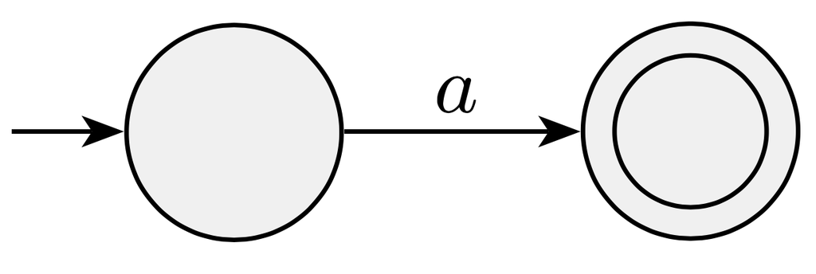

2. Si $R=\epsilon$ creamos el siguiente AFN

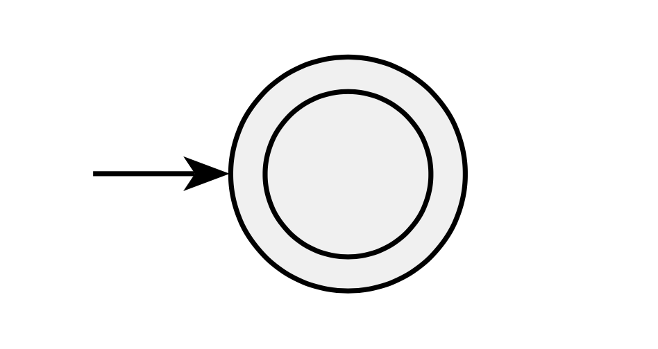

3. Si $R=\emptyset$ creamos el siguiente AFN

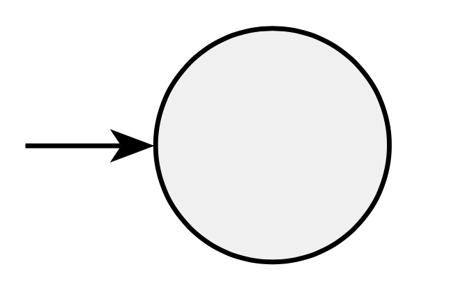

4. Para $R+S$, creamos el siguiente AFN

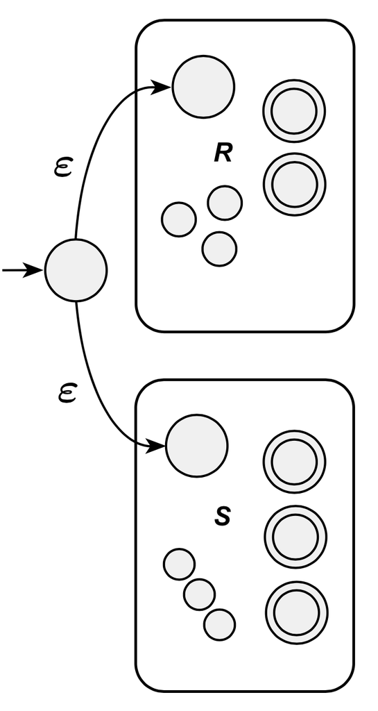

5. Para $R\cdot S$ , creamos el siguiente AFN

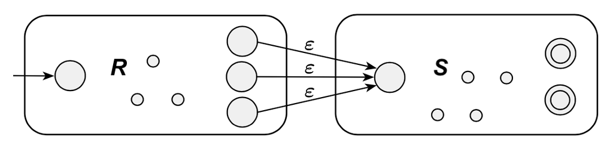

6. Para $R^∗$, creamos el siguiente AFN

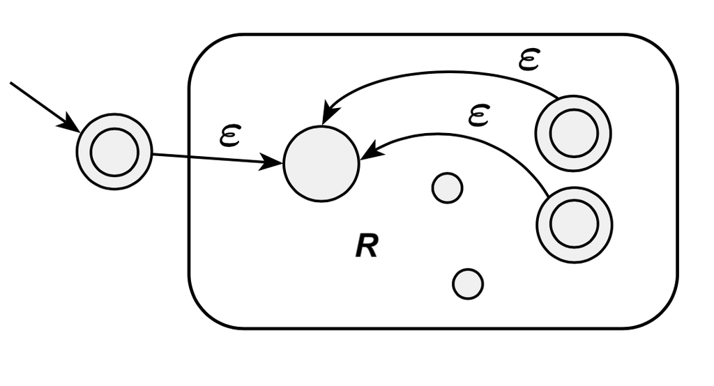

- Convertir la expresión regular $(ab + a)^∗$ a un NFA

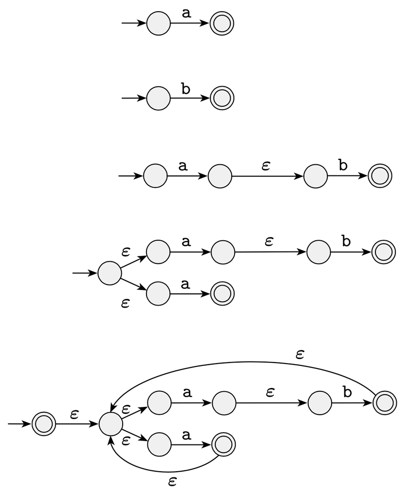

- Se puede encontrar un AFN con menos estados.

## EXPRESIONES REGULARES

### EJERCICIOS

- Convertir las siguientes expresion regulares a AFN
  - $(0+1)^{*}1(0+1)$
  - $(0+1)^{*}000(0+1)^{*}$
  - $((00)^{*}11+01)^{*}$
  - $\emptyset^{*}$
  - $\epsilon^{*}$
  - $((0+1)^{*}(11)^{*}+0)^{*}$
  - $(\emptyset + \epsilon + a^{*}b + \epsilon^{*})^{*}$
  - $((a+b^{*}+ab)^{*} b^{*} + baa^{*})^{*}$

## EXPRESIONES REGULARES

- `TEOREMA`: Un lenguaje es regular si o solo si existe una expresión regular que lo describe
  - Prueba por casos
- `LEMA`: Si un lenguaje es regular, entonces existe una expresión regular que lo describe
- Idea de la prueba:
- Dado un AFD $A$ que reconoce un lenguaje, debemos construir una expresión regular que describe el mismo lenguaje.
- Paso 1: Transformar $A$ en un AFN Generalizado (AFDG) $B$
- Paso 2: Transformar el AFNG $B$ en una expresión regular
- Que es un AFN Generalizado?
  - Es un AFN cuyas transiciones pueden tener expresiones regulares.
  - En cada paso puede leer **bloques de símbolos** de la entrada.
  - Si la correspondiente expresión regular concuerda con el bloque leído entonces el AFNG hace la respectiva transición
- `Ejemplo`:

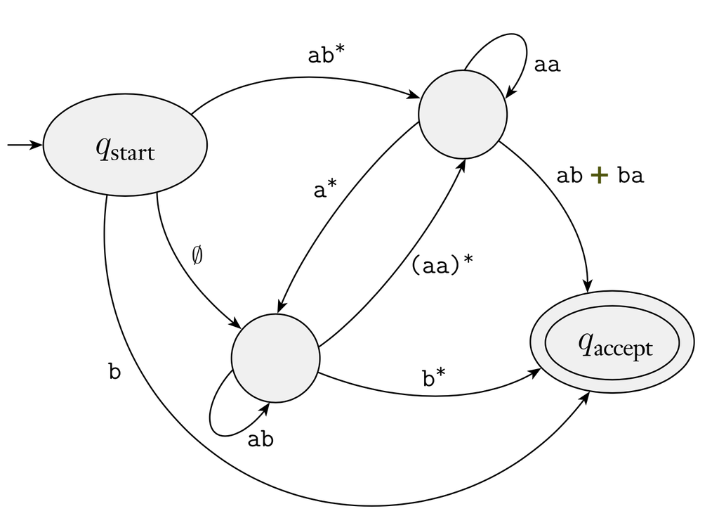

- Paso 1: Cómo transformar un AFD $A$ en un AFNG $B$?
  - Adicionamos dos nuevos estados: $q_{inicio}$ y $q_{final}$
  - El estado inicial de $B$ es ahora $q_{inicio}$ y el estado final es $q_{final}$
  - Adicionamos transiciones $\epsilon$ desde $q_{inicio}$ hacia el antiguo estado inicial
  - Adicionamos transiciones $\epsilon$ desde los antiguos estados finales hacia $q_{final}$

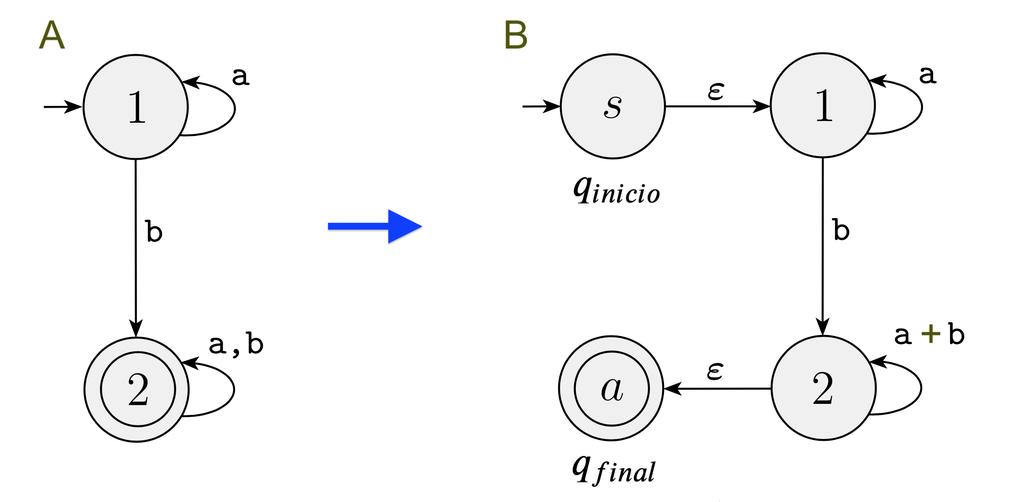

- Paso 2: Cómo transformar un AFNG $B$ en una expresión regular?
  - Supongamos que $B$ tiene $k$ estados
  - $k>2$ entonces removemos un estado (de una manera especial)
  - Repetimos este paso hasta que $k=2$
  - Cuando $k=2$, la transición desde $q_{inicio}$ hasta $q_{final}$ contendrá la expresión regular buscada
- Cómo remover un estado del AFNG $B$?
  - Elegimos un estado para remover, llamemoslo $q_{rip}$, diferente de $q_{inicio}$ y $q_{final}$
  - Después de remover $q_{rip}$ debemos `reparar` el autómata, alterando las transiciones entre todos los otros estados
  - Tomemos dos estados $q_i$ y $q_j$ (que no son $q_{rip}$)
    1. Suponga que $q_i$ va hacia $q_{rip}$ con transición $R_1$
    2. Suponga que $q_{rip}$ va hacia $q_{rip}$ con transición $R_2$
    3. Suponga que $q_{rip}$ va hacia $q_{j}$ con transición $R_3$
    4. Suponga que $q_i$ va hacia $q_{j}$ con transición $R_4$

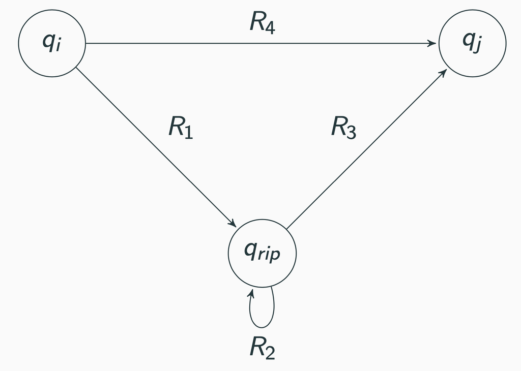

- Entonces, $q_i$ va hacia $q_{j}$ con transición $(R_1)(R_2)^{*}(R_3)+R_4$

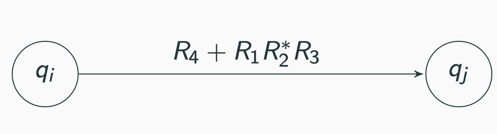

- `Ejemplo`:

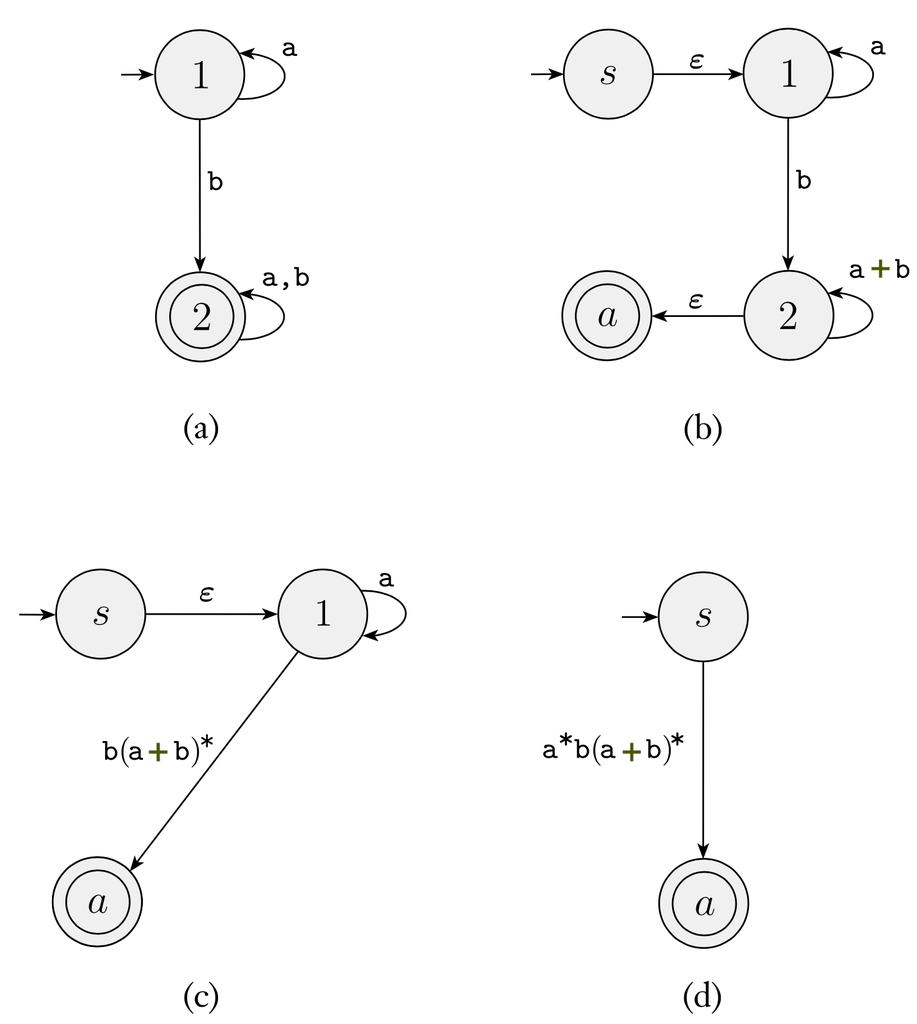

- `Ejemplo`: Transformar el siguiente AFD a expresión regular.

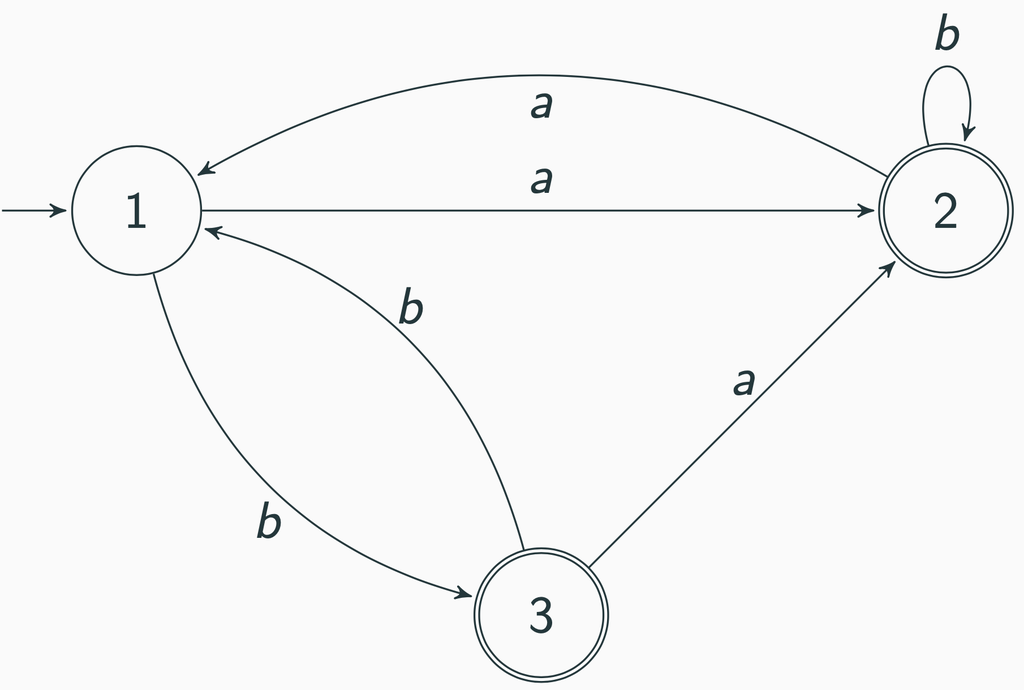

## CONCLUSIONES

### En esta sesión aprendiste

- El concepto operaciones regulares de lenguajes
- El concepto, uso y diseño expresiones regulares
- El concepto de lenguajes descritos por expresiones regulares
- Las expresiones regulares son equivalentes a los AFD y AFN